# Testosterone Gene Expression Prediction — Subclass

Sneha M. Chaturvedi, Emma Jones

Last updated 2026-09-04

Testosterone–gene limma-voom at the subclass-level cell type annotation.

| **Inputs** | `data/cache/pb_base_subclass.rds`, `doc/targeted/targeted_hormones.xlsx` |
| --- | --- |
| **Outputs** | `results/gene-hormone/testosterone_genes_subclass/` |
| **Upstream** | `prep_data.R` |
| **Downstream** | None |

## Goals

Identify genes whose pseudobulk expression is predicted by testosterone (TT) concentration, by **subclass**. Analysis is **sex-separate**: XX and XY samples are modeled independently within each subclass.

**Four models tested:**

- **Base** — `~ TT`
- **Base + GW** — `~ TT + GW` (gestational week as additive covariate; justified by covariate testing)
- **Base + Batch** — `~ TT + batch1_frac` (batch1 fraction as a continuous additive covariate; both batches draw cells from the same biological samples but differ in which cells were captured)
- **Base + GW + Batch** — `~ TT + GW + batch1_frac` (both covariates)

## Set Up

- Load packages

```r
    Packages <- c(
      "tidyverse", "Seurat", "Signac", "glue", "readxl", "cowplot",
      "edgeR", "limma", "patchwork", "svglite", "Matrix", "ggpubr"
    )
    lapply(Packages, library, character.only = TRUE)

    source("pseudobulk_functions.R")
root <- find_project_root()

    set.seed(123)
```

```r
    SSD_data <- readRDS(file.path(root, "data/cache/SSD_meta_umap.rds"))
    pb_base   <- readRDS(file.path(root, "data/cache/pb_base_subclass.rds"))
    targeted_comparison_raw <- read_xlsx(file.path(root, "doc/targeted/targeted_hormones.xlsx"))
    targeted_comparison_raw$E2 <- targeted_comparison_raw$`17B-E2 (ng/mL)`
    targeted_comparison_raw$TT <- targeted_comparison_raw$`TT (ng/mL)`
    targeted_comparison_raw$P4 <- targeted_comparison_raw$`P4 (ng/mL)`
```

- Configuration

```r
    celltype_col      <- "subclass"
    sample_col        <- "Sample"
    pb_sample_pattern <- "tissue\\d+"

    out_base <- file.path(root, "results/gene-hormone/testosterone_genes_subclass")

    for (sub in c("run_voom_lm", "run_voom_lm_gw",
                  "run_voom_lm_batch", "run_voom_lm_gw_batch")) {
      dir.create(file.path(out_base, sub), recursive = TRUE, showWarnings = FALSE)
    }
```

## Outlier Removal

Samples with TT > Q3 + 1.5 × IQR are excluded before pseudobulk construction.

```r
detect_outliers <- function(data, variable) {
  outlier_limit <- quantile(data[[variable]], 0.75, na.rm = TRUE) +
    1.5 * IQR(data[[variable]], na.rm = TRUE)
  data %>% dplyr::filter(.data[[variable]] <= outlier_limit)
}

targeted_comparison_filtered_TT <- detect_outliers(targeted_comparison_raw, "TT")

cat("Samples before outlier removal:", nrow(targeted_comparison_raw), "\n")
```

```
## Samples before outlier removal: 46
```

```r
cat("Samples after outlier removal: ", nrow(targeted_comparison_filtered_TT), "\n")
```

```
## Samples after outlier removal:  43
```

```r
cat("TT range after filtering:      ",
    paste(round(range(targeted_comparison_filtered_TT$TT, na.rm = TRUE), 3),
          collapse = " – "), "ng/mL\n")
```

```
## TT range after filtering:       0 – 0.224 ng/mL
```

## Pseudobulk

Min 30 cells per (sample × subclass) for inclusion. `add_batch_fraction()` computes the fraction of batch1 cells per biological sample and joins it onto the pseudobulk metadata.

```r
pb_TT <- merge_hormone_metadata(
  pb_base,
  targeted_comparison_filtered_TT,
  pb_sample_pattern = pb_sample_pattern,
  min_cells         = 30
)

pb_TT <- add_batch_fraction(pb_TT, SSD_data)

cat("Pseudobulk samples after merge:", nrow(pb_TT$metadata), "\n")
```

```
## Pseudobulk samples after merge: 295
```

```r
cat("batch1_frac summary:\n")
```

```
## batch1_frac summary:
```

```r
print(summary(pb_TT$metadata$batch1_frac))
```

```
##    Min. 1st Qu.  Median    Mean 3rd Qu.    Max.
##  0.0000  0.1815  0.3741  0.4027  0.5645  1.0000
```

```r
cat("NAs in batch1_frac:", sum(is.na(pb_TT$metadata$batch1_frac)), "\n")
```

```
## NAs in batch1_frac: 0
```

## Models

| Model | Formula | Rationale |
| --- | --- | --- |
| Base | `~ TT` | Direct TT–gene association |
| Base + GW | `~ TT + GW` | GW predicts transcriptome-wide expression (covariate testing) |
| Base + Batch | `~ TT + batch1_frac` | Absorbs residual expression differences between batches; continuous encoding matches the non-bimodal batch composition |
| Base + GW + Batch | `~ TT + GW + batch1_frac` | Both covariates adjusted simultaneously |

All models use `analyze_hormone()`: splits by (subclass × Sex), applies manual gene filter, drops groups below sample threshold, fits limma-voom per group.

## Base Model

`~ TT` — sex-separate, no covariates.

```r
res_TT_base <- analyze_hormone(
  pb_TT$counts, pb_TT$metadata,
  hormone               = "TT",
  min_samples           = 10,
  count_threshold       = 2,
  gene_sample_threshold = 3,
  model                 = run_voom_lm
)
```

```
##
## Group: Astrocyte.F
## Initial number of samples: 10
## Min samples required (fixed floor): 10
## Genes passing manual filter: 13870
## Samples with non-zero hormone: 2
## Group removed: insufficient non-zero hormone values 2
##
## Group: Cajal-Retzius cell.F
## Initial number of samples: 4
## Min samples required (fixed floor): 10
## Genes passing manual filter: 9227
## Samples with non-zero hormone: 0
## Group removed: insufficient non-zero hormone values 0
##
## Group: EN-DL.F
## Initial number of samples: 18
## Min samples required (fixed floor): 10
## Genes passing manual filter: 26909
## Samples with non-zero hormone: 5
## Group removed: insufficient non-zero hormone values 5
##
## Group: EN-Newborn.F
## Initial number of samples: 19
## Min samples required (fixed floor): 10
## Genes passing manual filter: 23171
## Samples with non-zero hormone: 6
## Group removed: insufficient non-zero hormone values 6
##
## Group: EN-UL.F
## Initial number of samples: 17
## Min samples required (fixed floor): 10
## Genes passing manual filter: 24993
## Samples with non-zero hormone: 5
## Group removed: insufficient non-zero hormone values 5
##
## Group: IN-CGE.F
## Initial number of samples: 16
## Min samples required (fixed floor): 10
## Genes passing manual filter: 16027
```

[output cut: 111 more lines]

```
## Group removed: insufficient non-zero hormone values 3
##
## Group: OPC.M
## Initial number of samples: 12
## Min samples required (fixed floor): 10
## Genes passing manual filter: 14008
## Samples with non-zero hormone: 12
## Final sample size: 12
##
## Group: Radial glia.M
## Initial number of samples: 11
## Min samples required (fixed floor): 10
## Genes passing manual filter: 16144
## Samples with non-zero hormone: 11
## Final sample size: 11
```

```r
summary_TT_base <- summarize_sig_genes(res_TT_base$combined_results)

plot_top_genes_from_subsets(
  res_TT_base$by_group_data,
  output_dir = file.path(out_base, "run_voom_lm"),
  hormone    = "TT"
)
```

```
## Number of groups to plot: 9
```

```
##  Plotting group: Astrocyte_M
```

```
## - Significant genes (FDR < 0.1, |logFC| >= 0.25): 0
```

```
## No valid plots for group
```

```
##  Plotting group: EN-DL_M
```

```
## - Significant genes (FDR < 0.1, |logFC| >= 0.25): 0
```

```
## No valid plots for group
```

```
##  Plotting group: EN-Newborn_M
```

```
## - Significant genes (FDR < 0.1, |logFC| >= 0.25): 0
```

```
## No valid plots for group
```

```
##  Plotting group: EN-UL_M
```

```
## - Significant genes (FDR < 0.1, |logFC| >= 0.25): 0
```

```
## No valid plots for group
```

```
##  Plotting group: IN-CGE_M
```

```
## - Significant genes (FDR < 0.1, |logFC| >= 0.25): 0
```

```
## No valid plots for group
```

```
##  Plotting group: IN-MGE_M
```

```
## - Significant genes (FDR < 0.1, |logFC| >= 0.25): 0
```

```
## No valid plots for group
```

```
##  Plotting group: IPC-EN_M
```

```
## - Significant genes (FDR < 0.1, |logFC| >= 0.25): 1
```

```
##     Plotting gene: F13A1 (adj. p-value: 0.0984)
```

```
## Saved: IPC-EN_M_top_genes.png  +  svg/IPC-EN_M_top_genes.svg
##   Saved plot for IPC-EN_M
##  Plotting group: OPC_M
## - Significant genes (FDR < 0.1, |logFC| >= 0.25): 0
## No valid plots for group
##  Plotting group: Radial glia_M
## - Significant genes (FDR < 0.1, |logFC| >= 0.25): 0
## No valid plots for group
```

```r
save_dual_format(
  plot_sig_gene_summary(summary_TT_base, "TT — Base (~ TT) | Subclass"),
  output_dir    = file.path(out_base, "run_voom_lm"),
  filename_base = "TT_base_sig_gene_summary"
)
```

```
## Saved: TT_base_sig_gene_summary.png  +  svg/TT_base_sig_gene_summary.svg
```

```r
write_csv(res_TT_base$combined_results,
          file.path(out_base, "run_voom_lm", "TT_base_results.csv"))
write_csv(summary_TT_base,
          file.path(out_base, "run_voom_lm", "TT_base_summary.csv"))
```

### Significant Genes

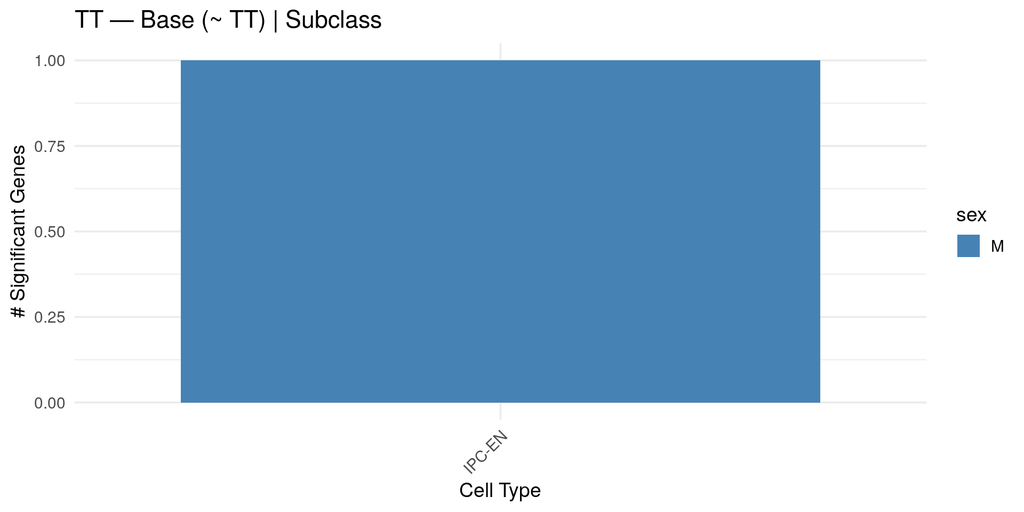

```r
plot_sig_gene_summary(summary_TT_base, "TT — Base (~ TT) | Subclass")
```

### Top Results

```r
res_TT_base$combined_results %>%
  dplyr::arrange(adj.P.Val) %>%
  dplyr::select(gene, cell_type, sex, logFC, adj.P.Val) %>%
  head(10) %>%
  knitr::kable(digits = 4, caption = "Top 10 hits — Base model")
```

Top 10 hits — Base model

| gene | cell_type | sex | logFC | adj.P.Val |
| --- | --- | --- | --- | --- |
| F13A1 | IPC-EN | M | 28.6387 | 0.0984 |
| SLC4A10 | Radial glia | M | 12.8829 | 0.2298 |
| HNMT | EN-Newborn | M | -22.3103 | 0.3632 |
| ENSG00000228655 | EN-Newborn | M | 16.8899 | 0.3632 |
| FSTL1 | EN-Newborn | M | 13.0531 | 0.3632 |
| CLDN1 | EN-Newborn | M | 41.2831 | 0.3632 |
| LINC00504 | EN-Newborn | M | 10.4227 | 0.3632 |
| LDB2 | EN-Newborn | M | 20.2052 | 0.3632 |
| TACR3 | EN-Newborn | M | 28.1572 | 0.3632 |
| ENSG00000248242 | EN-Newborn | M | 18.0566 | 0.3632 |

## Base + GW

`~ TT + GW` — gestational week as additive covariate.

```r
res_TT_gw <- analyze_hormone(
  pb_TT$counts, pb_TT$metadata,
  hormone               = "TT",
  min_samples           = 10,
  count_threshold       = 2,
  gene_sample_threshold = 3,
  model                 = run_voom_lm_gw
)
```

```
##
## Group: Astrocyte.F
## Initial number of samples: 10
## Min samples required (fixed floor): 10
## Genes passing manual filter: 13870
## Samples with non-zero hormone: 2
## Group removed: insufficient non-zero hormone values 2
##
## Group: Cajal-Retzius cell.F
## Initial number of samples: 4
## Min samples required (fixed floor): 10
## Genes passing manual filter: 9227
## Samples with non-zero hormone: 0
## Group removed: insufficient non-zero hormone values 0
##
## Group: EN-DL.F
## Initial number of samples: 18
## Min samples required (fixed floor): 10
## Genes passing manual filter: 26909
## Samples with non-zero hormone: 5
## Group removed: insufficient non-zero hormone values 5
##
## Group: EN-Newborn.F
## Initial number of samples: 19
## Min samples required (fixed floor): 10
## Genes passing manual filter: 23171
## Samples with non-zero hormone: 6
## Group removed: insufficient non-zero hormone values 6
##
## Group: EN-UL.F
## Initial number of samples: 17
## Min samples required (fixed floor): 10
## Genes passing manual filter: 24993
## Samples with non-zero hormone: 5
## Group removed: insufficient non-zero hormone values 5
##
## Group: IN-CGE.F
## Initial number of samples: 16
## Min samples required (fixed floor): 10
## Genes passing manual filter: 16027
```

[output cut: 111 more lines]

```
## Group removed: insufficient non-zero hormone values 3
##
## Group: OPC.M
## Initial number of samples: 12
## Min samples required (fixed floor): 10
## Genes passing manual filter: 14008
## Samples with non-zero hormone: 12
## Final sample size: 12
##
## Group: Radial glia.M
## Initial number of samples: 11
## Min samples required (fixed floor): 10
## Genes passing manual filter: 16144
## Samples with non-zero hormone: 11
## Final sample size: 11
```

```r
summary_TT_gw <- summarize_sig_genes(res_TT_gw$combined_results)

plot_top_genes_from_subsets(
  res_TT_gw$by_group_data,
  output_dir = file.path(out_base, "run_voom_lm_gw"),
  hormone    = "TT"
)
```

```
## Number of groups to plot: 9
```

```
##  Plotting group: Astrocyte_M
```

```
## - Significant genes (FDR < 0.1, |logFC| >= 0.25): 0
```

```
## No valid plots for group
```

```
##  Plotting group: EN-DL_M
```

```
## - Significant genes (FDR < 0.1, |logFC| >= 0.25): 0
```

```
## No valid plots for group
```

```
##  Plotting group: EN-Newborn_M
```

```
## - Significant genes (FDR < 0.1, |logFC| >= 0.25): 0
```

```
## No valid plots for group
```

```
##  Plotting group: EN-UL_M
```

```
## - Significant genes (FDR < 0.1, |logFC| >= 0.25): 0
```

```
## No valid plots for group
```

```
##  Plotting group: IN-CGE_M
```

```
## - Significant genes (FDR < 0.1, |logFC| >= 0.25): 0
```

```
## No valid plots for group
```

```
##  Plotting group: IN-MGE_M
```

```
## - Significant genes (FDR < 0.1, |logFC| >= 0.25): 0
```

```
## No valid plots for group
```

```
##  Plotting group: IPC-EN_M
```

```
## - Significant genes (FDR < 0.1, |logFC| >= 0.25): 0
```

```
## No valid plots for group
```

```
##  Plotting group: OPC_M
```

```
## - Significant genes (FDR < 0.1, |logFC| >= 0.25): 0
```

```
## No valid plots for group
```

```
##  Plotting group: Radial glia_M
```

```
## - Significant genes (FDR < 0.1, |logFC| >= 0.25): 0
```

```
## No valid plots for group
```

```r
save_dual_format(
  plot_sig_gene_summary(summary_TT_gw, "TT — Base + GW (~ TT + GW) | Subclass"),
  output_dir    = file.path(out_base, "run_voom_lm_gw"),
  filename_base = "TT_gw_sig_gene_summary"
)
```

```
## Saved: TT_gw_sig_gene_summary.png  +  svg/TT_gw_sig_gene_summary.svg
```

```r
write_csv(res_TT_gw$combined_results,
          file.path(out_base, "run_voom_lm_gw", "TT_gw_results.csv"))
write_csv(summary_TT_gw,
          file.path(out_base, "run_voom_lm_gw", "TT_gw_summary.csv"))
```

### Significant Genes

[figure not shown]

```r
plot_sig_gene_summary(summary_TT_gw, "TT — Base + GW (~ TT + GW) | Subclass")
```

### Top Results

```r
res_TT_gw$combined_results %>%
  dplyr::arrange(adj.P.Val) %>%
  dplyr::select(gene, cell_type, sex, logFC, adj.P.Val) %>%
  head(10) %>%
  knitr::kable(digits = 4, caption = "Top 10 hits — Base + GW model")
```

Top 10 hits — Base + GW model

| gene | cell_type | sex | logFC | adj.P.Val |
| --- | --- | --- | --- | --- |
| FBXL7 | EN-UL | M | -15.5969 | 0.3140 |
| TCF7L1 | EN-Newborn | M | -15.7074 | 0.3537 |
| HNMT | EN-Newborn | M | -22.2879 | 0.3537 |
| FSTL1 | EN-Newborn | M | 12.8891 | 0.3537 |
| BMPR1B | EN-Newborn | M | -16.0209 | 0.3537 |
| ENSG00000248242 | EN-Newborn | M | 18.5305 | 0.3537 |
| KLHL32 | EN-Newborn | M | -17.8530 | 0.3537 |
| ENSG00000287097 | EN-Newborn | M | 12.7449 | 0.3537 |
| NACC2 | EN-Newborn | M | -16.1801 | 0.3537 |
| SLIT1 | EN-Newborn | M | 15.5896 | 0.3537 |

## Base + Batch

`~ TT + batch1_frac` — batch1 fraction (continuous) as additive covariate.

```r
res_TT_batch <- analyze_hormone(
  pb_TT$counts, pb_TT$metadata,
  hormone               = "TT",
  min_samples           = 10,
  count_threshold       = 2,
  gene_sample_threshold = 3,
  model                 = run_voom_lm_batch
)
```

```
##
## Group: Astrocyte.F
## Initial number of samples: 10
## Min samples required (fixed floor): 10
## Genes passing manual filter: 13870
## Samples with non-zero hormone: 2
## Group removed: insufficient non-zero hormone values 2
##
## Group: Cajal-Retzius cell.F
## Initial number of samples: 4
## Min samples required (fixed floor): 10
## Genes passing manual filter: 9227
## Samples with non-zero hormone: 0
## Group removed: insufficient non-zero hormone values 0
##
## Group: EN-DL.F
## Initial number of samples: 18
## Min samples required (fixed floor): 10
## Genes passing manual filter: 26909
## Samples with non-zero hormone: 5
## Group removed: insufficient non-zero hormone values 5
##
## Group: EN-Newborn.F
## Initial number of samples: 19
## Min samples required (fixed floor): 10
## Genes passing manual filter: 23171
## Samples with non-zero hormone: 6
## Group removed: insufficient non-zero hormone values 6
##
## Group: EN-UL.F
## Initial number of samples: 17
## Min samples required (fixed floor): 10
## Genes passing manual filter: 24993
## Samples with non-zero hormone: 5
## Group removed: insufficient non-zero hormone values 5
##
## Group: IN-CGE.F
## Initial number of samples: 16
## Min samples required (fixed floor): 10
## Genes passing manual filter: 16027
```

[output cut: 111 more lines]

```
## Group removed: insufficient non-zero hormone values 3
##
## Group: OPC.M
## Initial number of samples: 12
## Min samples required (fixed floor): 10
## Genes passing manual filter: 14008
## Samples with non-zero hormone: 12
## Final sample size: 12
##
## Group: Radial glia.M
## Initial number of samples: 11
## Min samples required (fixed floor): 10
## Genes passing manual filter: 16144
## Samples with non-zero hormone: 11
## Final sample size: 11
```

```r
summary_TT_batch <- summarize_sig_genes(res_TT_batch$combined_results)

plot_top_genes_from_subsets(
  res_TT_batch$by_group_data,
  output_dir = file.path(out_base, "run_voom_lm_batch"),
  hormone    = "TT"
)
```

```
## Number of groups to plot: 9
```

```
##  Plotting group: Astrocyte_M
```

```
## - Significant genes (FDR < 0.1, |logFC| >= 0.25): 0
```

```
## No valid plots for group
```

```
##  Plotting group: EN-DL_M
```

```
## - Significant genes (FDR < 0.1, |logFC| >= 0.25): 0
```

```
## No valid plots for group
```

```
##  Plotting group: EN-Newborn_M
```

```
## - Significant genes (FDR < 0.1, |logFC| >= 0.25): 0
```

```
## No valid plots for group
```

```
##  Plotting group: EN-UL_M
```

```
## - Significant genes (FDR < 0.1, |logFC| >= 0.25): 0
```

```
## No valid plots for group
```

```
##  Plotting group: IN-CGE_M
```

```
## - Significant genes (FDR < 0.1, |logFC| >= 0.25): 0
```

```
## No valid plots for group
```

```
##  Plotting group: IN-MGE_M
```

```
## - Significant genes (FDR < 0.1, |logFC| >= 0.25): 0
```

```
## No valid plots for group
```

```
##  Plotting group: IPC-EN_M
```

```
## - Significant genes (FDR < 0.1, |logFC| >= 0.25): 0
```

```
## No valid plots for group
```

```
##  Plotting group: OPC_M
```

```
## - Significant genes (FDR < 0.1, |logFC| >= 0.25): 0
```

```
## No valid plots for group
```

```
##  Plotting group: Radial glia_M
```

```
## - Significant genes (FDR < 0.1, |logFC| >= 0.25): 0
```

```
## No valid plots for group
```

```r
save_dual_format(
  plot_sig_gene_summary(summary_TT_batch, "TT — Base + Batch (~ TT + batch1_frac) | Subclass"),
  output_dir    = file.path(out_base, "run_voom_lm_batch"),
  filename_base = "TT_batch_sig_gene_summary"
)
```

```
## Saved: TT_batch_sig_gene_summary.png  +  svg/TT_batch_sig_gene_summary.svg
```

```r
write_csv(res_TT_batch$combined_results,
          file.path(out_base, "run_voom_lm_batch", "TT_batch_results.csv"))
write_csv(summary_TT_batch,
          file.path(out_base, "run_voom_lm_batch", "TT_batch_summary.csv"))
```

### Significant Genes

[figure not shown]

```r
plot_sig_gene_summary(summary_TT_batch, "TT — Base + Batch (~ TT + batch1_frac) | Subclass")
```

### Top Results

```r
res_TT_batch$combined_results %>%
  dplyr::arrange(adj.P.Val) %>%
  dplyr::select(gene, cell_type, sex, logFC, adj.P.Val) %>%
  head(10) %>%
  knitr::kable(digits = 4, caption = "Top 10 hits — Base + Batch model")
```

Top 10 hits — Base + Batch model

| gene | cell_type | sex | logFC | adj.P.Val |
| --- | --- | --- | --- | --- |
| F13A1 | IPC-EN | M | 28.8483 | 0.1545 |
| SLC4A10 | Radial glia | M | 12.9242 | 0.3713 |
| FSTL1 | EN-Newborn | M | 13.1912 | 0.3906 |
| ENSG00000228655 | EN-Newborn | M | 16.9221 | 0.5482 |
| CLDN1 | EN-Newborn | M | 41.8053 | 0.5482 |
| LINC00504 | EN-Newborn | M | 10.4255 | 0.5482 |
| LDB2 | EN-Newborn | M | 19.9809 | 0.5482 |
| ENSG00000248242 | EN-Newborn | M | 18.0065 | 0.5482 |
| KLKB1 | EN-Newborn | M | 16.0338 | 0.5482 |
| CDH6 | EN-Newborn | M | 21.7798 | 0.5482 |

## Base + GW + Batch

`~ TT + GW + batch1_frac` — gestational week and batch1 fraction as simultaneous additive covariates.

```r
res_TT_gw_batch <- analyze_hormone(
  pb_TT$counts, pb_TT$metadata,
  hormone               = "TT",
  min_samples           = 10,
  count_threshold       = 2,
  gene_sample_threshold = 3,
  model                 = run_voom_lm_gw_batch
)
```

```
##
## Group: Astrocyte.F
## Initial number of samples: 10
## Min samples required (fixed floor): 10
## Genes passing manual filter: 13870
## Samples with non-zero hormone: 2
## Group removed: insufficient non-zero hormone values 2
##
## Group: Cajal-Retzius cell.F
## Initial number of samples: 4
## Min samples required (fixed floor): 10
## Genes passing manual filter: 9227
## Samples with non-zero hormone: 0
## Group removed: insufficient non-zero hormone values 0
##
## Group: EN-DL.F
## Initial number of samples: 18
## Min samples required (fixed floor): 10
## Genes passing manual filter: 26909
## Samples with non-zero hormone: 5
## Group removed: insufficient non-zero hormone values 5
##
## Group: EN-Newborn.F
## Initial number of samples: 19
## Min samples required (fixed floor): 10
## Genes passing manual filter: 23171
## Samples with non-zero hormone: 6
## Group removed: insufficient non-zero hormone values 6
##
## Group: EN-UL.F
## Initial number of samples: 17
## Min samples required (fixed floor): 10
## Genes passing manual filter: 24993
## Samples with non-zero hormone: 5
## Group removed: insufficient non-zero hormone values 5
##
## Group: IN-CGE.F
## Initial number of samples: 16
## Min samples required (fixed floor): 10
## Genes passing manual filter: 16027
```

[output cut: 111 more lines]

```
## Group removed: insufficient non-zero hormone values 3
##
## Group: OPC.M
## Initial number of samples: 12
## Min samples required (fixed floor): 10
## Genes passing manual filter: 14008
## Samples with non-zero hormone: 12
## Final sample size: 12
##
## Group: Radial glia.M
## Initial number of samples: 11
## Min samples required (fixed floor): 10
## Genes passing manual filter: 16144
## Samples with non-zero hormone: 11
## Final sample size: 11
```

```r
summary_TT_gw_batch <- summarize_sig_genes(res_TT_gw_batch$combined_results)

plot_top_genes_from_subsets(
  res_TT_gw_batch$by_group_data,
  output_dir = file.path(out_base, "run_voom_lm_gw_batch"),
  hormone    = "TT"
)
```

```
## Number of groups to plot: 9
```

```
##  Plotting group: Astrocyte_M
```

```
## - Significant genes (FDR < 0.1, |logFC| >= 0.25): 0
```

```
## No valid plots for group
```

```
##  Plotting group: EN-DL_M
```

```
## - Significant genes (FDR < 0.1, |logFC| >= 0.25): 0
```

```
## No valid plots for group
```

```
##  Plotting group: EN-Newborn_M
```

```
## - Significant genes (FDR < 0.1, |logFC| >= 0.25): 0
```

```
## No valid plots for group
```

```
##  Plotting group: EN-UL_M
```

```
## - Significant genes (FDR < 0.1, |logFC| >= 0.25): 0
```

```
## No valid plots for group
```

```
##  Plotting group: IN-CGE_M
```

```
## - Significant genes (FDR < 0.1, |logFC| >= 0.25): 0
```

```
## No valid plots for group
```

```
##  Plotting group: IN-MGE_M
```

```
## - Significant genes (FDR < 0.1, |logFC| >= 0.25): 0
```

```
## No valid plots for group
```

```
##  Plotting group: IPC-EN_M
```

```
## - Significant genes (FDR < 0.1, |logFC| >= 0.25): 0
```

```
## No valid plots for group
```

```
##  Plotting group: OPC_M
```

```
## - Significant genes (FDR < 0.1, |logFC| >= 0.25): 0
```

```
## No valid plots for group
```

```
##  Plotting group: Radial glia_M
```

```
## - Significant genes (FDR < 0.1, |logFC| >= 0.25): 0
```

```
## No valid plots for group
```

```r
save_dual_format(
  plot_sig_gene_summary(summary_TT_gw_batch,
                        "TT — Base + GW + Batch (~ TT + GW + batch1_frac) | Subclass"),
  output_dir    = file.path(out_base, "run_voom_lm_gw_batch"),
  filename_base = "TT_gw_batch_sig_gene_summary"
)
```

```
## Saved: TT_gw_batch_sig_gene_summary.png  +  svg/TT_gw_batch_sig_gene_summary.svg
```

```r
write_csv(res_TT_gw_batch$combined_results,
          file.path(out_base, "run_voom_lm_gw_batch", "TT_gw_batch_results.csv"))
write_csv(summary_TT_gw_batch,
          file.path(out_base, "run_voom_lm_gw_batch", "TT_gw_batch_summary.csv"))
```

### Significant Genes

[figure not shown]

```r
plot_sig_gene_summary(summary_TT_gw_batch,
                      "TT — Base + GW + Batch (~ TT + GW + batch1_frac) | Subclass")
```

### Top Results

```r
res_TT_gw_batch$combined_results %>%
  dplyr::arrange(adj.P.Val) %>%
  dplyr::select(gene, cell_type, sex, logFC, adj.P.Val) %>%
  head(10) %>%
  knitr::kable(digits = 4, caption = "Top 10 hits — Base + GW + Batch model")
```

Top 10 hits — Base + GW + Batch model

| gene | cell_type | sex | logFC | adj.P.Val |
| --- | --- | --- | --- | --- |
| F13A1 | IPC-EN | M | 28.9766 | 0.5595 |
| ERICH3 | EN-UL | M | 9.1348 | 0.5705 |
| FBXL7 | EN-UL | M | -15.2242 | 0.5705 |
| DIAPH3 | EN-UL | M | 24.0085 | 0.5705 |
| SERINC2 | EN-Newborn | M | -9.5616 | 0.5959 |
| LINC01748 | EN-Newborn | M | 21.3010 | 0.5959 |
| ENSG00000231252 | EN-Newborn | M | 17.8540 | 0.5959 |
| ERICH3-AS1 | EN-Newborn | M | 20.4374 | 0.5959 |
| LRRC8B | EN-Newborn | M | 7.8361 | 0.5959 |
| ARHGAP29 | EN-Newborn | M | 23.7941 | 0.5959 |

## Summary

```r
cross_model_TT <- dplyr::bind_rows(
  summarize_sig_genes(res_TT_base$combined_results)     %>%
    dplyr::mutate(model = "~ TT"),
  summarize_sig_genes(res_TT_gw$combined_results)       %>%
    dplyr::mutate(model = "~ TT + GW"),
  summarize_sig_genes(res_TT_batch$combined_results)    %>%
    dplyr::mutate(model = "~ TT + batch1_frac"),
  summarize_sig_genes(res_TT_gw_batch$combined_results) %>%
    dplyr::mutate(model = "~ TT + GW + batch1_frac")
)

knitr::kable(
  cross_model_TT %>%
    dplyr::select(model, cell_type, sex, num_sig_genes) %>%
    dplyr::arrange(model, desc(num_sig_genes)),
  caption = "Significant genes (FDR < 0.10, |logFC| ≥ 0.25) per model"
)
```

Significant genes (FDR < 0.10, |logFC| ≥ 0.25) per model

| model | cell_type | sex | num_sig_genes |
| --- | --- | --- | --- |
| ~ TT | IPC-EN | M | 1 |

```r
cross_model_TT %>%
  dplyr::group_by(model) %>%
  dplyr::summarise(total_sig_genes = sum(num_sig_genes), .groups = "drop") %>%
  knitr::kable(caption = "Total significant genes per model")
```

Total significant genes per model

| model | total_sig_genes |
| --- | --- |
| ~ TT | 1 |

## Analysis UMAP

Cells included in the testosterone analysis: from (subclass × XY) groups that passed all thresholds. XY cells from included groups are colored by subclass; all XX cells and cells from excluded subclasses are shown in grey.

```r
plot_analysis_umap(
  seurat_obj    = SSD_data,
  by_group_data = res_TT_base$by_group_data,
  title         = "Testosterone Analysis — Included Cells (XY) | Subclass",
  celltype_col  = celltype_col,
  sex_separate  = TRUE,
  output_dir    = out_base,
  filename_base = "TT_analysis_umap"
)
```

```
## plot_analysis_umap [Testosterone Analysis — Included Cells (XY) | Subclass]: 65030 included cells (51.4%), 61459 excluded
```

```
## Saved: TT_analysis_umap.png  +  svg/TT_analysis_umap.svg
```

## AI Assistance Disclosure

Code in this script was developed with assistance from Claude (Anthropic). All AI-generated code was reviewed, validated, and adapted by the author.